# Stochastic Gradient Langevin Dynamic algorithm

…on a mixture model

Georgios P. Karagiannis @ MATH3431 Machine Learning and Neural Networks III

[Back to README](https://github.com/georgios-stats/Machine_Learning_and_Neural_Networks_III_Epiphany_2025/tree/main?tab=readme-ov-file#computer-lab-notes)

```r
rm(list=ls())
```

*Aim*

Students will become able to:

- practice in R,
- implement SGLD algorithm in R
- use Normal mixture model

In the computer room, students will practice on the binary classification problem.

Students are suggested to practice on the Mixture model example at home where the straightforward implementation of the SGLD is meant to fail.

*Reading material*

- Reference for *R*:
  - [Cheat sheet with basic commands](https://cran.r-project.org/doc/contrib/Short-refcard.pdf)
- Reference of *rmarkdown* (optional, supplementary material):
  - [R Markdown cheatsheet](https://raw.githubusercontent.com/rstudio/cheatsheets/main/rmarkdown-2.0.pdf)
  - [R Markdown Reference Guide](https://www.rstudio.com/wp-content/uploads/2015/03/rmarkdown-reference.pdf)
  - [knitr options](https://yihui.name/knitr/options)
- Reference for *Latex* (optional, supplementary material):

## [Latex Cheat Sheet](https://wch.github.io/latexsheet/latexsheet-a4.pdf)

*New software*

- R package base functions:
  - set.seed{base}
- R package numDeriv functions:
  - grad{numDeriv}
- R package mvtnorm functions:
  - dmvnorm{mvtnorm}

```r
# call libraries
library(numDeriv)
library(mvtnorm)
```

```r
# Load R package for printing
library(knitr)
```

```r
# Set a seed of the random number generator
set.seed(2023)
```

# 1 Mixture model

```r
rm( list = ls() )
```

This task is given as a supplementary material, for your information. You can do it at home for practice.

The following example is given as a homework practice.

The problem is non convex, there are two modes (maxima) (true values) in the posterior distribution.

You will see that you will not be able to visit both of the models (maxima) with one run.

You may need to perform several runs starting your algorithm from different seeds $w^{(0)}$.

Consider the Bayesian model below

$$\begin{cases}
z_{i}|w\overset{\text{ind}}{\sim}p_{1}\text{N}\left(w,\sigma^{2}\right)+\left(1-p_{1}\right)\text{N}\left(\phi-w,\sigma^{2}\right);\,i=1,...,n
& \text{ sampling distr. }\\
w\sim\text{N}\left(\mu,s^{2}\right) & \text{ prior }
\end{cases}$$

with fixed parameters $\phi=20$, $p_{1}=0.5$, $\sigma^{2}=5$, $\mu=0.0$, and $s^{2}=100$

```r
data_generating_model <- function(n,w) {
  z <- rep( NaN, times=n )
  p1 <- 0.5
  p2 <- 1.0-p1
  w <- 5
  phi <-  20
  sig2 <- 5
  lab <- as.numeric(runif(n_obs)>p1)
  z <- lab*rnorm(n, mean = w, sd = sqrt(sig2)) + (1-lab)*rnorm(n, mean = phi-w, sd = sqrt(sig2))
  return(z)
}
```

By inspecting the sampling distribution $f(z|w)$, you will find out that the true values here are $w=5$ and $w=15$ as both of them satisfy the likelihood.

Assume that the real values for the parameter $w$ is $w_{\text{true}}\in\{5,15\}$.

The dataset containing the examples to train the model are generated below, and stores in the array $z_{\text{obs}}$.

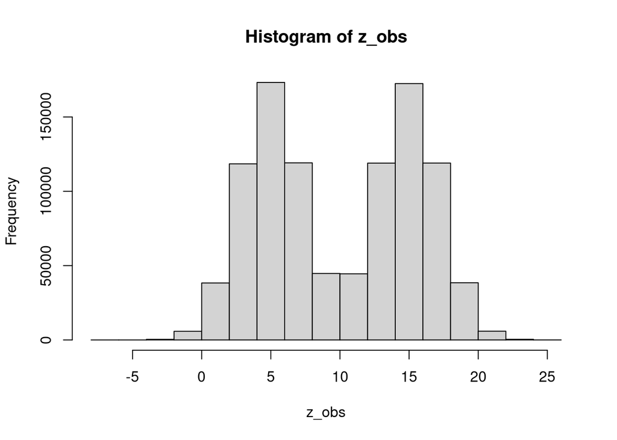

```r
n_obs <- 10^(6)
w_true <- 5
set.seed(2023)
z_obs <- data_generating_model(n = n_obs, w = w_true)
set.seed(0)
hist(z_obs)
```

## 1.1 Task

Code a function `log_sampling_pdf(z, w, p1 = 0.5, phi=20, sig2 = 5)’ that returns as a value the PDF of sampling distribution in log scale for a single example $z$.

You may use the function dnorm{stats} .

```r
log_sampling_pdf <- function(z, w, p1 = 0.5, phi=20, sig2 = 5) {
  log_sampling_pdf <- p1*dnorm(z, mean = w, sd = sqrt(sig2), log = FALSE)
  log_sampling_pdf <- log_sampling_pdf + (1-p1)*dnorm(z, mean = phi-w, sd = sqrt(sig2), log = FALSE)
  log_sampling_pdf <- log(log_sampling_pdf) ;
  return(log_sampling_pdf)
}
```

## 1.2 Task

The PDF of the prior distribution is Normal with mean $\mu=0.0$ and variance $s^{2}=100$.

$$f\left(w\right)=\text{N}\left(w|\mu=0.0,s^{2}=100\right)$$

You may use the function dnorm{stats} .

```r
log_prior_pdf <- function(w, mu = 0.0, sig2 = 100 ) {
  log_pdf <- dnorm(w, mean = mu, sd = sqrt(sig2), log = TRUE)
  return( log_pdf )
}
```

## 1.3 Task

Below is given the learning rate function learning_rate <- function(t, T_0 , T_1 = , C_0 , s_0 )

$$\eta_{t}=
\begin{cases}
C_{0}, & t \le T_{0} \\
\frac{C_{0}}{(t-T_{0})^{\varsigma}}, & T_{0}+1 \le t \le T_{1} \\
\frac{C_{0}}{(T_{1}-T_{0})^{\varsigma}}, & T_{1}+1 \le t
\end{cases}$$

for some constants $C_0$ and $\varsigma\in(0.5,1]$.

```r
learning_rate <- function(t, T_0  , T_1  , C_0  , s_0   ) {
  if ( t <= T_0 ) {
    eta <- C_0
  } else if ( (T_0+1 <= t) && (t <= T_1 ) ) {
    eta <- C_0 / ( (t-T_0) ^ s_0 )
  } else {
    eta <- C_0 / ( (T_1-T_0) ^ s_0 )
  }
  return(eta)
}
```

## 1.4 Task

Compute the gradient of the log pdf of the sampling distribution with respect to $w$ at point $w=4.0$ (at the 1st example; i.e. $z_{1}$).

Do this by using the function ‘grad{numDeriv}’ from the R package numDeriv.

E.g., you can use it as numDeriv::grad( fun, w ). You can try ?grad for more info.

```r
w <- 4.0
#
aux_fun <- function(w, z = z_obs[1]) {
  return( log_sampling_pdf(z, w) )
}
#
gr <- numDeriv::grad( aux_fun, w )
#
gr
```

```
## [1] 0.6026276
```

## 1.5 Task

Code a Stochastic Gradient Langevin Dynamics (SGLD) algorithm with batch size $m=?$, and temperature $\tau=?$ that returns the chain of all the $\{w^{(t)}\}$ produced. The learning rate can be constant for the first half of the run, with a decay $\varsigma=?$, and constant $C_{0}=?$.

The termination criterion is when the total number of iterations excesses $T_{\text{max}}=?$.

Seed with $w^{(0)}=0$.

You may use the R function grad{numDeriv} to numerically compute the gradient; e.g. numDeriv::grad( erf_fun, w ) . Try ?grad for more info.

After finishing your code, try to set the algorithmic parameters $m$, $\tau$, $\varsigma$, and constant $C_{0}$ and $T_{\text{max}}$, etc., with purpose to run the code and discover both modes.

Plot the trace plot and the histogram of the generated chain $\{w^{(t)}\}$. Did you visited both of the areas around the true values of $w$?. You may find out that the produced chain is prone to local trapping aka it is trapped to one mode and unable to cross the valley of low mass in order to visit the other mode. How to do modify GD, SGD, and SGLD in order to address such an issue, remains a challenge.

```r
Tmax <- 500
#
w_seed <- 0.0
#
eta <- 10^(-2)
eta_C <- eta
eta_s <- 0.51
eta_T0 <- 0.3*Tmax
eta_T1 <- 0.6*Tmax
#
batch_size <- 1000
#
tau <- 1.0
#
# Set the seed
w <- w_seed
w_chain_clipping <- c(w)
# iterate
t <- 1
Qterm <- 0
#
clipping_threshold <- 10
#
# iterate
#
while ( (Qterm != 1) ) {
  # counter
  t <- t+1
  cat( t ) ; cat( ' ' ) ## counter added for display reasons
  # learning rate
  eta <- learning_rate(t, eta_T0, eta_T1, eta_C, eta_s)
  # sub-sample
  J <- sample.int( n = n_obs, size = batch_size, replace = FALSE)
  # update
  w_new <- w
  ## likelihood
  grad_est_lik <- rep( 0.0, times=length(w) )
  for (j in J) {
    aux_fun <- function(w, z=z_obs[j]){
      gr <- log_sampling_pdf(z, w)
      return(gr)
    }
    grad_est_lik <- grad_est_lik + numDeriv::grad(aux_fun, w)
  }
  grad_est_lik <- ( n_obs / batch_size) * grad_est_lik
  # gradient clipping/rescaring
  norm_grad_est_lik <- sqrt(sum(grad_est_lik^2))
  grad_est_lik <- grad_est_lik * min( 1.0, clipping_threshold/norm_grad_est_lik )
  w_new <- w_new +eta*grad_est_lik ;
  ## prior
  aux_fun <- function(w){
    d <- length(w)
    gr <- log_prior_pdf(w, rep(0,d), 100*diag(d))
    return(gr)
  }
  w_new <- w_new +eta*numDeriv::grad(aux_fun, w) ;
  ## noise
  w_new <- w_new +sqrt(2.0)*sqrt(eta)*sqrt(tau)*rnorm(n = length(w), mean = 0, sd = 1)
  # record
  w <- w_new
  # termination criterion
  if  ( t >= Tmax ) {
    Qterm <- 1
  }
  # record the produced chain
  w_chain_clipping <- rbind(w_chain_clipping,w)
}
```

[output not shown]

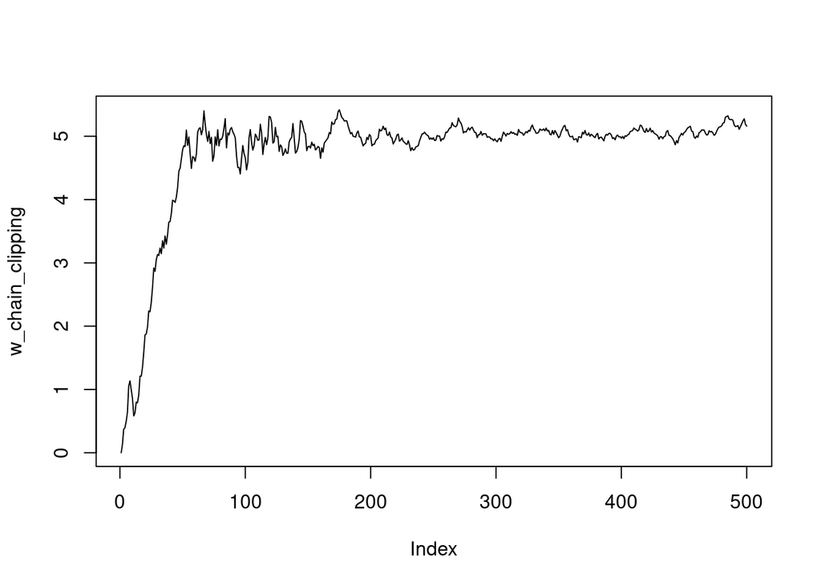

```r
plot(w_chain_clipping, type = 'l')
```

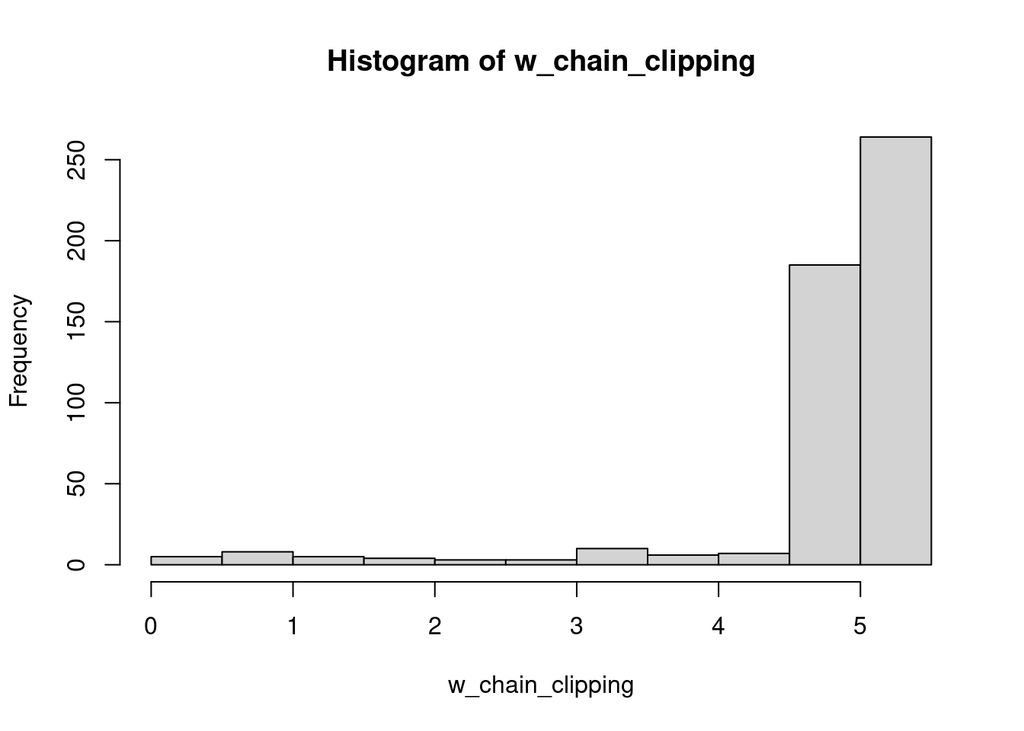

```r
hist(w_chain_clipping)
```